# 2026년 10월 월간 기업·산업 분석

TSMC 3분기 — 2나노 양산과 AI 파운드리 병목의 실적화

저자

Alpha Hunter

공개

2026년 10월 25일

**경고연구 목적 고지**

이 글은 공개 공시·기업 IR·실적 발표·증권사 공개 리서치·시장조사기관 공개자료를 바탕으로 한 **정보·연구 목적**의 기업·산업 분석이다. **투자자문이나 특정 증권의 매수·매도·보유 권유가 아니다.** 데이터 기준일은 **2026년 10월 25일**이며, 이후 발표·가격은 반영하지 않았다.

# 1 월간 결론

10월의 핵심은 AI 반도체 수요가 **TSMC의 매출 성장, HPC 비중, 2나노 매출, 4분기 가이던스**로 동시에 확인됐다는 점이다. 3분기 매출은 `NT$1.494조`로 전년 대비 `+50.9%`, 순이익은 `NT$7,631억`으로 `+68.7%` 증가했다. 달러 매출 `$46.72B`는 종전 가이던스 상단 `$45.8B`를 웃돌았다.

다만 성장과 위험은 같은 곳에 있다. HPC가 매출의 `68%`, 7나노 이하 선단공정이 웨이퍼 매출의 `79%`를 차지했다. AI 가속기와 선단공정 수요가 강할수록 고객·제품 집중, 막대한 설비투자, 해외 팹 비용, 지정학적 노출도 함께 커진다.

| 10월 체크포인트 | 확인치 | Alpha Hunter 해석 |
| --- | --- | --- |
| 3Q26 매출 | NT$1,494.24B / US$46.72B | 가이던스 상단을 넘은 선단공정 수요 |
| 3Q26 순이익 | NT$763.06B, YoY +68.7% | 매출 증가보다 큰 이익 레버리지 |
| 매출총이익률 / 영업이익률 | 66.4% / 58.7% | 초기 2나노 비용에도 높은 수익성 |
| 2나노 웨이퍼 매출 비중 | 8% | 양산 램프가 이미 손익계산서에 반영 |
| HPC 매출 비중 | 68%, QoQ +22% | AI·고성능컴퓨팅이 성장축 |
| 4Q26 매출 가이던스 | US$52.3~54.3B | 중간값 기준 QoQ 약 +14% |

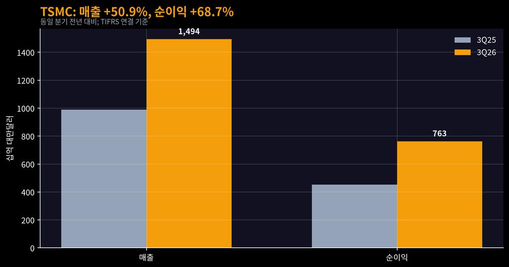

그림 1: 그림 1. TSMC 3Q26 핵심 실적. 출처: TSMC 3Q26 Earnings Release 및 SEC 6-K.

# 2 기업분석 — TSMC

## 2.1 실적: 성장률보다 중요한 믹스

3분기 달러 매출은 전년 대비 `41.2%`, 전분기 대비 `16.2%` 증가했다. 매출총이익률 `66.4%`, 영업이익률 `58.7%`, 순이익률 `51.1%`다. 2나노 초기 양산 비용으로 매출총이익률은 2분기 `67.7%`보다 낮아졌지만, 선단공정 믹스와 가동률이 높은 수익성을 지켰다.

플랫폼별로 HPC 매출은 전분기 대비 `22%` 늘어 전체의 `68%`를 차지했다. 스마트폰은 `+10%`, IoT는 `+5%`였다. 실적의 질은 범용 회복보다 **AI/HPC와 선단공정의 결합**에 가깝다.

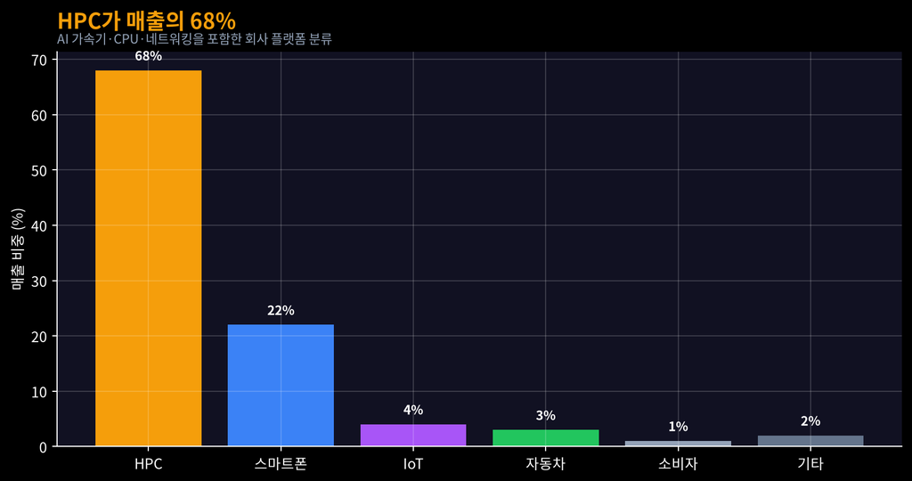

그림 2: 그림 2. TSMC 3Q26 플랫폼별 웨이퍼 매출 비중. 출처: TSMC 3Q26 Presentation.

## 2.2 2나노: 기술 발표가 아니라 매출 항목

2나노는 2분기 웨이퍼 매출의 `3%`에서 3분기 `8%`로 확대됐다. 3나노 `33%`, 5나노 `28%`, 7나노 `10%`를 합치면 7나노 이하가 `79%`다. 4분기 회사 가이던스는 매출 `$52.3~54.3B`, 매출총이익률 `65~67%`, 영업이익률 `56.5~58.5%`다. 중간값은 3분기 대비 매출 약 `14.1%` 증가를 뜻한다.

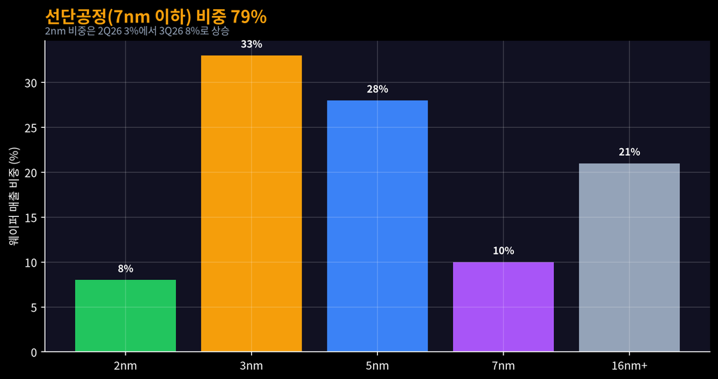

그림 3: 그림 3. TSMC 3Q26 공정별 웨이퍼 매출 비중. 출처: TSMC 3Q26 Presentation.

## 2.3 증권사 시각: 숫자는 참고하되 목표가는 분리

KGI Singapore는 10월 19일 공개 노트에서 3분기 매출이 시장 예상보다 약 `$1.10B` 높았고, 회사가 2026년 달러 매출 성장률 전망을 약 `44%`로 높였다고 정리했다. 의견은 긍정적이지만, 이 저널은 목표가나 매매 의견을 채택하지 않는다. 증권사 해석은 공식 실적과 가이던스를 읽는 보조자료로만 사용했다.

# 3 산업분석 — 파운드리의 병목이 넓어진다

## 3.1 선단공정: 2나노 램프와 설비투자

TSMC의 3분기 자본지출은 `NT$443.21B`였다. 높은 선단공정 수요는 매출을 끌어올리는 동시에 현금 집행과 감가상각을 늘린다. 4분기 매출 가이던스의 상승과 마진 가이던스의 정체는 이 두 힘이 동시에 작동함을 보여준다.

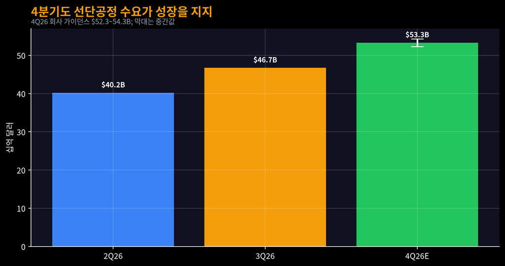

그림 4: 그림 4. TSMC 분기 달러 매출과 4Q26 가이던스. 출처: TSMC 3Q26 Earnings Release. 4Q는 범위와 중간값.

## 3.2 첨단패키징·실리콘포토닉스: 후공정까지 이어지는 공급 제약

TrendForce의 10월 5일 파운드리 업데이트는 TSMC가 일부 성숙공정 설비를 CoWoS 인터포저와 실리콘포토닉스에 활용하는 흐름을 짚었다. 이는 AI 칩 병목이 전공정 미세화 하나로 끝나지 않고 **인터포저·패키징·광연결**로 넓어진다는 뜻이다. 다만 해당 자료의 세부 시장 규모는 유료 영역이므로, 공개 요약을 넘어선 수치를 추정하지 않았다.

메모리 쪽에서도 같은 방향이 보인다. TrendForce는 4분기 일반 DRAM 계약가격 `+10~15% QoQ`, NAND Flash `+15~20%`를 전망했고, 기업용 SSD의 2026년 비트 수요가 `80% 이상` 늘 것으로 봤다. AI 시스템의 병목은 파운드리 웨이퍼, HBM, 기업용 SSD, 패키징·테스트가 연결된 **공급망 전체의 처리량** 문제다.

## 3.3 위험 지도

| 위험 | 확인 신호 | 다음 점검 |
| --- | --- | --- |
| AI/HPC 집중 | HPC 매출 비중 68% | 고객별 주문 조정과 가속기 세대 전환 |
| 2나노 초기 비용 | 2nm 비중 8%, GM 66.4% | 4Q GM 가이던스 65~67% 달성 여부 |
| 설비투자·감가상각 | 3Q CapEx NT$443.21B | 2027년 가동률과 해외 팹 희석 효과 |
| 공급망 병목 이동 | CoWoS·SiPh·eSSD 수요 | 패키징 증설이 실제 출하로 전환되는 속도 |
| 지정학 | 대만 생산 집중과 해외 증설 | 지역별 원가·보조금·수출통제 변화 |
| 수요의 비대칭 | AI 강세, 소비자 수요 압박 | 스마트폰·PC 재고와 메모리 가격 전가 |

# 4 11월에 확인할 항목

1. TSMC 10월 월매출에서 4분기 가이던스 진입 속도를 확인한다.
2. 2나노 매출 비중 상승과 매출총이익률 희석 폭을 함께 본다.
3. CoWoS·실리콘포토닉스 증설 발표와 실제 가동 시점을 구분한다.
4. 기업용 SSD 강세가 파운드리·컨트롤러·패키징 매출로 전이되는지 확인한다.
5. SK hynix 3분기 실적은 10월 28일 발표 예정이므로 이번 기준일에는 추정하지 않았다. 발표 후 메모리 공급망 숫자를 후속 점검한다.

# 5 출처와 재현 기준

공개 접근 가능한 공식 IR·공시·시장조사기관·증권사 자료 **8개**를 사용했다. 유료 리포트 전문, 비공개 IR, 실시간 계좌·개인정보는 사용하지 않았다.

- [TSMC, 3Q26 Earnings Release, 2026-10-15](https://investor.tsmc.com/english/quarterly-results/2026/q3)
- [TSMC, 3Q26 Presentation, 2026-10-15](https://investor.tsmc.com/english/quarterly-results/2026/q3)
- [TSMC, 3Q26 Earnings Call Transcript, 2026-10-15](https://investor.tsmc.com/english/quarterly-results/2026/q3)
- [SEC, TSMC 3Q26 results Exhibit 99.1 / Form 6-K, 2026-10-15](https://www.sec.gov/Archives/edgar/data/1046179/000104617926000726/a3q26e_withguidancexfinal.htm)
- [TSMC, September 2026 Monthly Revenue, 2026-10-08](https://investor.tsmc.com/english/monthly-revenue/2026)
- [TrendForce, Foundry Market Bulletin public summary, 2026-10-05](https://www.trendforce.com/research/download/RP261005QL3)
- [TrendForce, AI Server Demand Sustains Memory Contract Price Increases in 4Q26, 2026-09-30](https://www.trendforce.com/presscenter/news/20260930-13258.html)
- [KGI Singapore Research, Technical Analysis, 2026-10-19](https://www.kgieworld.sg/research/technical-analysis-19-october-2026/)

차트는 위 공개값을 문서 안에 고정해 재현했다. 시장 전망과 회사 가이던스는 실적이 아니며, 전망치에는 `E` 또는 범위를 표시했다.